# Testing Meta Functions

2026-08-18

# 1 Read in data

To start, we will read in our stomach data, which includes the study name (authors and year), location, type of talc, observed counts, expected counts, effect estimate (EE), and the lower and upper bound of the 95% Confidence intervals corresponding with the EE.

```r
stomach_dat <- read_excel("stomach_dat.xlsx") |>
  rename_with(tolower) |>
  mutate(study = str_replace_all(study, "\\r\\n|\\r|\\n", " ")) |> #cleaning up output for character strings
  filter(!is.na(study))
head(stomach_dat)
```

```
## # A tibble: 6 × 8
##   study       location talc_type observed expected    ee lower_bound upper_bound
##   <chr>       <chr>    <chr>        <dbl> <chr>    <dbl>       <dbl>       <dbl>
## 1 Negri et a… italy    industri…       35 45.08    0.78        0.54         1.08
## 2 Bulbulyan … russia   industri…       29 31.3     0.9         0.6          1.3
## 3 Chang et a… german   industri…       45 1804     2.13        1.54         2.94
## 4 Straif et … german   industri…       44 -        1.17       85          157
## 5 Fordyce et… vermont  cosmetic         2 -        0.749       0.091        2.70
## 6 Honda et a… NY       industri…        2 1.4      1.44        0.17         5.2
```

## 1.1 Log-transformation and standard error calculation

Next, we need to create two variables.

We need to log-transform the ee, and derive the standard error from the log-transformed lower and upper bound. We will do so by taking the width of the CI and dividing by (2*1.96). It would be best if we had the n for each and could calculate using a t-distribution, but we didn’t have that in our data, so instead we will use the z-value

```r
stomach_dat <- stomach_dat |>
  mutate(
        log_ee = log10(ee),
         se = ( (log(upper_bound) - log(lower_bound)) / (2 * qnorm(0.975)))
    )

stomach_dat |>
  select(study,ee,log_ee,lower_bound,upper_bound,se) |>
  head()
```

```
## # A tibble: 6 × 6
##   study                       ee  log_ee lower_bound upper_bound    se
##   <chr>                    <dbl>   <dbl>       <dbl>       <dbl> <dbl>
## 1 Negri et al. (1989)      0.78  -0.108        0.54         1.08 0.177
## 2 Bulbulyan et al.  (1999) 0.9   -0.0458       0.6          1.3  0.197
## 3 Chang et al. (2019)      2.13   0.328        1.54         2.94 0.165
## 4 Straif et al.  (2000)    1.17   0.0682      85          157    0.157
## 5 Fordyce et al.  (2019)   0.749 -0.126        0.091        2.70 0.865
## 6 Honda et al. (2002)      1.44   0.158        0.17         5.2  0.873
```

Note that the escalc function is actually quite useful for this in particular, which we don’t even have to write anew.

Let’s try to get this into a plot before we write the functions and start afresh:

# 2 Meta-analysis

**Calculating meta**

```r
stomachmeta <- rma(yi = stomach_dat$log_ee, vi = stomach_dat$se, method = "DL", slab = stomach_dat$study)
summary(stomachmeta) #print results
```

```
##
## Random-Effects Model (k = 9; tau^2 estimator: DL)
##
##   logLik  deviance       AIC       BIC      AICc
##  -2.9444    0.7076    9.8887   10.2832   11.8887
##
## tau^2 (estimated amount of total heterogeneity): 0 (SE = 0.1229)
## tau (square root of estimated tau^2 value):      0
## I^2 (total heterogeneity / total variability):   0.00%
## H^2 (total variability / sampling variability):  1.00
##
## Test for Heterogeneity:
## Q(df = 8) = 0.7076, p-val = 0.9995
##
## Model Results:
##
## estimate      se    zval    pval    ci.lb   ci.ub
##   0.0625  0.1630  0.3837  0.7012  -0.2569  0.3820
##
## ---
## Signif. codes:  0 '***' 0.001 '**' 0.01 '*' 0.05 '.' 0.1 ' ' 1
```

```r
predict(stomachmeta, transf=exp)
```

```
##
##    pred  ci.lb  ci.ub  pi.lb  pi.ub
##  1.0645 0.7734 1.4652 0.7734 1.4652
```

## 2.1 Cumulative Forest plot

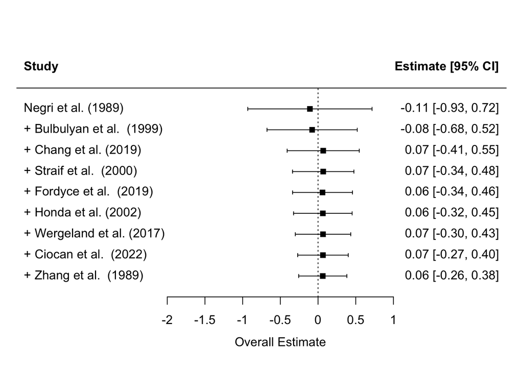

```r
x <- cumul(stomachmeta) #Cumulative repeatedly fits specified model adding one study at a time
forest(x, xlim=c(-4,2.5), alim=c(-2,1), steps=7, slab= stomach_dat$study)
```

## 2.2 Funnel Plot

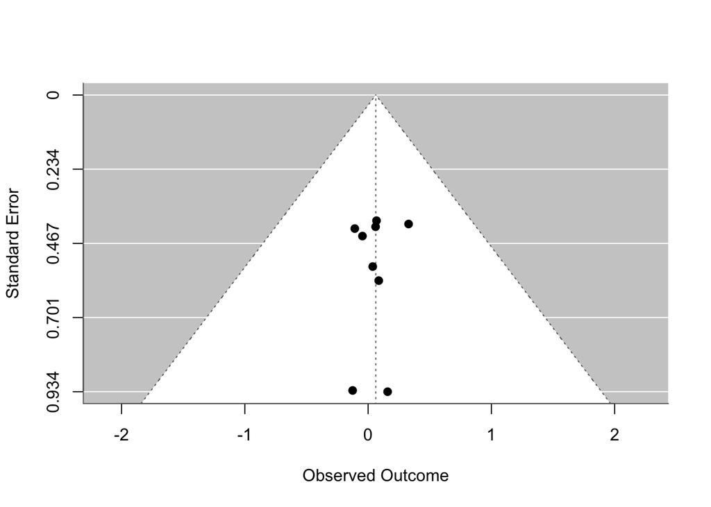

```r
funnel(stomachmeta)
```